# HR Data Analytics

### Data Extraction From Kaggle.com

```python
import pandas as pd
```

```python
#%pip install pandoc
#%pip install kaggle
```

```python
import kaggle
```

```python
!kaggle datasets download hopesb/hr-analytics-dataset -f Messy_HR_Dataset_Detailed.csv
```

```
Dataset URL: https://www.kaggle.com/datasets/hopesb/hr-analytics-dataset
License(s): apache-2.0
Messy_HR_Dataset_Detailed.csv: Skipping, found more recently modified local copy (use --force to force download)
```

### Data Cleaning & Transformation

```python
df = pd.read_csv('Messy_HR_Dataset_Detailed.csv')
df
```

|  | Unnamed: 0 | FirstName | LastName | StartDate | ExitDate | Title | Supervisor | ADEmail | BusinessUnit | EmployeeStatus | ... | Satisfaction Score | Work-Life Balance Score | Training Date | Training Program Name | Training Type | Training Outcome | Location | Trainer | Training Duration(Days) | Training Cost |
| --- | --- | --- | --- | --- | --- | --- | --- | --- | --- | --- | --- | --- | --- | --- | --- | --- | --- | --- | --- | --- | --- |
| 0 | 0 | Uriah | Bridges | 20-Sep-19 | NaN | Production Technician I | Peter Oneill | uriah.bridges@bilearner.com | CCDR | Active | ... | 2 | 3 | 15-Jul-23 | Leadership Development | Internal | Failed | South Marisa | Taylor Rodriguez | 2 | 606.11 |
| 1 | 1 | Paula | Small | 11-Feb-23 | NaN | Production Technician I | Renee Mccormick | paula.small@bilearner.com | EW | Active | ... | 1 | 5 | 12-Sep-22 | Customer Service | External | Incomplete | Tammieville | Kelly Patterson DDS | 4 | 673.02 |
| 2 | 2 | Edward | Buck | 10-Dec-18 | NaN | Area Sales Manager | Crystal Walker | edward.buck@bilearner.com | PL | Active | ... | 2 | 1 | 13-Aug-22 | Leadership Development | External | Failed | East Roberthaven | Taylor Thomas | 2 | 413.28 |
| 3 | 3 | Michael | Riordan | 21-Jun-21 | NaN | Area Sales Manager | Rebekah Wright | michael.riordan@bilearner.com | CCDR | Active | ... | 5 | 4 | 15-Dec-22 | Project Management | External | Completed | Garzatown | Holly Elliott | 3 | 663.78 |
| 4 | 4 | Jasmine | Onque | 29-Jun-19 | NaN | Area Sales Manager | Jason Kim | jasmine.onque@bilearner.com | TNS | Active | ... | 5 | 3 | 13-Jul-23 | Technical Skills | External | Failed | Lake Meganville | Donald Martinez | 5 | 399.03 |
| ... | ... | ... | ... | ... | ... | ... | ... | ... | ... | ... | ... | ... | ... | ... | ... | ... | ... | ... | ... | ... | ... |
| 3145 | 450 | Oscar | Lopez | 22-Oct-18 | 07-Apr-20 | Network Engineer | Christian Ortega | oscar.lopez@bilearner.com | MSC | Active | ... | 3 | 4 | 04-Jun-23 | Communication Skills | External | Passed | Markhaven | Jeremy Townsend | 1 | 888.55 |
| 3146 | 2164 | Cruz | Arellano | 17-Sep-19 | NaN | Area Sales Manager | Patricia Martinez | cruz.arellano@bilearner.com | SVG | Active | ... | 5 | 5 | 06-Oct-22 | Customer Service | Internal | Completed | North Michaelbury | Jacob Johnson | 2 | 745.31 |
| 3147 | 2372 | Makenna | Foster | 20-Apr-21 | 17-Sep-22 | Production Technician I | Timothy Pratt | makenna.foster@bilearner.com | CCDR | Active | ... | 1 | 1 | 28-Jul-23 | Communication Skills | Internal | Incomplete | Stephaniemouth | Debbie Arnold | 1 | 543.46 |
| 3148 | 2012 | Cordell | Vazquez | 21-Aug-21 | NaN | Production Manager | Paula Henderson | cordell.vazquez@bilearner.com | BPC | Active | ... | 3 | 5 | 29-Oct-22 | Project Management | External | Failed | Port Joshuaborough | Shelby Fields | 4 | 816.24 |
| 3149 | 270 | Sonia | Skinner | 28-Jun-20 | NaN | Production Technician II | Connor Galloway | sonia.skinner@bilearner.com | PYZ | Active | ... | 4 | 1 | 24-Apr-23 | Technical Skills | Internal | Failed | East Vincent | Jennifer Lopez | 2 | 982.33 |

3150 rows × 39 columns

```python
df.drop(columns=['Unnamed: 0'], inplace=True)
df
```

|  | FirstName | LastName | StartDate | ExitDate | Title | Supervisor | ADEmail | BusinessUnit | EmployeeStatus | EmployeeType | ... | Satisfaction Score | Work-Life Balance Score | Training Date | Training Program Name | Training Type | Training Outcome | Location | Trainer | Training Duration(Days) | Training Cost |
| --- | --- | --- | --- | --- | --- | --- | --- | --- | --- | --- | --- | --- | --- | --- | --- | --- | --- | --- | --- | --- | --- |
| 0 | Uriah | Bridges | 20-Sep-19 | NaN | Production Technician I | Peter Oneill | uriah.bridges@bilearner.com | CCDR | Active | Contract | ... | 2 | 3 | 15-Jul-23 | Leadership Development | Internal | Failed | South Marisa | Taylor Rodriguez | 2 | 606.11 |
| 1 | Paula | Small | 11-Feb-23 | NaN | Production Technician I | Renee Mccormick | paula.small@bilearner.com | EW | Active | Contract | ... | 1 | 5 | 12-Sep-22 | Customer Service | External | Incomplete | Tammieville | Kelly Patterson DDS | 4 | 673.02 |
| 2 | Edward | Buck | 10-Dec-18 | NaN | Area Sales Manager | Crystal Walker | edward.buck@bilearner.com | PL | Active | Full-Time | ... | 2 | 1 | 13-Aug-22 | Leadership Development | External | Failed | East Roberthaven | Taylor Thomas | 2 | 413.28 |
| 3 | Michael | Riordan | 21-Jun-21 | NaN | Area Sales Manager | Rebekah Wright | michael.riordan@bilearner.com | CCDR | Active | Contract | ... | 5 | 4 | 15-Dec-22 | Project Management | External | Completed | Garzatown | Holly Elliott | 3 | 663.78 |
| 4 | Jasmine | Onque | 29-Jun-19 | NaN | Area Sales Manager | Jason Kim | jasmine.onque@bilearner.com | TNS | Active | Contract | ... | 5 | 3 | 13-Jul-23 | Technical Skills | External | Failed | Lake Meganville | Donald Martinez | 5 | 399.03 |
| ... | ... | ... | ... | ... | ... | ... | ... | ... | ... | ... | ... | ... | ... | ... | ... | ... | ... | ... | ... | ... | ... |
| 3145 | Oscar | Lopez | 22-Oct-18 | 07-Apr-20 | Network Engineer | Christian Ortega | oscar.lopez@bilearner.com | MSC | Active | Part-Time | ... | 3 | 4 | 04-Jun-23 | Communication Skills | External | Passed | Markhaven | Jeremy Townsend | 1 | 888.55 |
| 3146 | Cruz | Arellano | 17-Sep-19 | NaN | Area Sales Manager | Patricia Martinez | cruz.arellano@bilearner.com | SVG | Active | Full-Time | ... | 5 | 5 | 06-Oct-22 | Customer Service | Internal | Completed | North Michaelbury | Jacob Johnson | 2 | 745.31 |
| 3147 | Makenna | Foster | 20-Apr-21 | 17-Sep-22 | Production Technician I | Timothy Pratt | makenna.foster@bilearner.com | CCDR | Active | Part-Time | ... | 1 | 1 | 28-Jul-23 | Communication Skills | Internal | Incomplete | Stephaniemouth | Debbie Arnold | 1 | 543.46 |
| 3148 | Cordell | Vazquez | 21-Aug-21 | NaN | Production Manager | Paula Henderson | cordell.vazquez@bilearner.com | BPC | Active | Contract | ... | 3 | 5 | 29-Oct-22 | Project Management | External | Failed | Port Joshuaborough | Shelby Fields | 4 | 816.24 |
| 3149 | Sonia | Skinner | 28-Jun-20 | NaN | Production Technician II | Connor Galloway | sonia.skinner@bilearner.com | PYZ | Active | Full-Time | ... | 4 | 1 | 24-Apr-23 | Technical Skills | Internal | Failed | East Vincent | Jennifer Lopez | 2 | 982.33 |

3150 rows × 38 columns

```python
date_columns = ['StartDate', 'ExitDate', 'DOB', 'Survey Date', 'Training Date']
for col in date_columns:
    if col in df:
        df[col] = pd.to_datetime(df[col], format='%d-%b-%y', errors='coerce')
```

```python
#df.dtypes
#df.columns
```

### Cleanup Weird Characters For Column Names

```python
import pandas as pd
import re

def to_snake_case(name):
    name = re.sub(r'([A-Z]+)([A-Z][a-z])', r'\1_\2', name)
    name = re.sub(r'([a-z0-9])([A-Z])', r'\1_\2', name)

    name = name.replace(' ', '_')

    name = re.sub(r'[^a-zA-Z0-9_]', '', name)

    name = re.sub(r'__+', '_', name)

    return name.lower().strip('_')

df.columns = [to_snake_case(col) for col in df.columns]

print(df.columns)
```

```
Index(['first_name', 'last_name', 'start_date', 'exit_date', 'title',
       'supervisor', 'ad_email', 'business_unit', 'employee_status',
       'employee_type', 'pay_zone', 'employee_classification_type',
       'termination_type', 'termination_description', 'department_type',
       'division', 'dob', 'state', 'job_function_description', 'gender_code',
       'location_code', 'race_desc', 'marital_desc', 'performance_score',
       'current_employee_rating', 'employee_id', 'survey_date',
       'engagement_score', 'satisfaction_score', 'worklife_balance_score',
       'training_date', 'training_program_name', 'training_type',
       'training_outcome', 'location', 'trainer', 'training_durationdays',
       'training_cost'],
      dtype='object')
```

```python
df
```

|  | first_name | last_name | start_date | exit_date | title | supervisor | ad_email | business_unit | employee_status | employee_type | ... | satisfaction_score | worklife_balance_score | training_date | training_program_name | training_type | training_outcome | location | trainer | training_durationdays | training_cost |
| --- | --- | --- | --- | --- | --- | --- | --- | --- | --- | --- | --- | --- | --- | --- | --- | --- | --- | --- | --- | --- | --- |
| 0 | Uriah | Bridges | 2019-09-20 | NaT | Production Technician I | Peter Oneill | uriah.bridges@bilearner.com | CCDR | Active | Contract | ... | 2 | 3 | 2023-07-15 | Leadership Development | Internal | Failed | South Marisa | Taylor Rodriguez | 2 | 606.11 |
| 1 | Paula | Small | 2023-02-11 | NaT | Production Technician I | Renee Mccormick | paula.small@bilearner.com | EW | Active | Contract | ... | 1 | 5 | 2022-09-12 | Customer Service | External | Incomplete | Tammieville | Kelly Patterson DDS | 4 | 673.02 |
| 2 | Edward | Buck | 2018-12-10 | NaT | Area Sales Manager | Crystal Walker | edward.buck@bilearner.com | PL | Active | Full-Time | ... | 2 | 1 | 2022-08-13 | Leadership Development | External | Failed | East Roberthaven | Taylor Thomas | 2 | 413.28 |
| 3 | Michael | Riordan | 2021-06-21 | NaT | Area Sales Manager | Rebekah Wright | michael.riordan@bilearner.com | CCDR | Active | Contract | ... | 5 | 4 | 2022-12-15 | Project Management | External | Completed | Garzatown | Holly Elliott | 3 | 663.78 |
| 4 | Jasmine | Onque | 2019-06-29 | NaT | Area Sales Manager | Jason Kim | jasmine.onque@bilearner.com | TNS | Active | Contract | ... | 5 | 3 | 2023-07-13 | Technical Skills | External | Failed | Lake Meganville | Donald Martinez | 5 | 399.03 |
| ... | ... | ... | ... | ... | ... | ... | ... | ... | ... | ... | ... | ... | ... | ... | ... | ... | ... | ... | ... | ... | ... |
| 3145 | Oscar | Lopez | 2018-10-22 | 2020-04-07 | Network Engineer | Christian Ortega | oscar.lopez@bilearner.com | MSC | Active | Part-Time | ... | 3 | 4 | 2023-06-04 | Communication Skills | External | Passed | Markhaven | Jeremy Townsend | 1 | 888.55 |
| 3146 | Cruz | Arellano | 2019-09-17 | NaT | Area Sales Manager | Patricia Martinez | cruz.arellano@bilearner.com | SVG | Active | Full-Time | ... | 5 | 5 | 2022-10-06 | Customer Service | Internal | Completed | North Michaelbury | Jacob Johnson | 2 | 745.31 |
| 3147 | Makenna | Foster | 2021-04-20 | 2022-09-17 | Production Technician I | Timothy Pratt | makenna.foster@bilearner.com | CCDR | Active | Part-Time | ... | 1 | 1 | 2023-07-28 | Communication Skills | Internal | Incomplete | Stephaniemouth | Debbie Arnold | 1 | 543.46 |
| 3148 | Cordell | Vazquez | 2021-08-21 | NaT | Production Manager | Paula Henderson | cordell.vazquez@bilearner.com | BPC | Active | Contract | ... | 3 | 5 | 2022-10-29 | Project Management | External | Failed | Port Joshuaborough | Shelby Fields | 4 | 816.24 |
| 3149 | Sonia | Skinner | 2020-06-28 | NaT | Production Technician II | Connor Galloway | sonia.skinner@bilearner.com | PYZ | Active | Full-Time | ... | 4 | 1 | 2023-04-24 | Technical Skills | Internal | Failed | East Vincent | Jennifer Lopez | 2 | 982.33 |

3150 rows × 38 columns

```python
df.drop(columns=['dob'], inplace=True)
```

```python
# df.to_csv('cleaned_hr_data.csv', index=False)
```

### Connecting To MySQL Workbench Database

```python
# %pip install sqlalchemy
import sqlalchemy
```

```python
engine = sqlalchemy.create_engine('mysql+pymysql://root:Rohith18#@localhost:3306/hr_analytics')
```

```python
# df.to_sql('cleaned_hr_data', con=engine, if_exists='replace', index=False)
# hr_data = pd.read_sql_table('cleaned_hr_data', engine)
# hr_data
```

### Exploratory Data Analysis Using Pandas, Matplotlib & MySQL

##### Question-1: Attrition Trend Analysis "We need to understand our employee turnover. Can you provide the monthly attrition rate for the past year, broken down by department and employee classification type?"

##### Department Wise Attrition Rate (%)

```python
department_wise_attrition_rate = '''
WITH exits AS (
    SELECT
        TRIM(department_type) AS department_type,
        COUNT(*) AS exits
    FROM cleaned_hr_data
    WHERE exit_date BETWEEN '2023-01-01' AND '2023-08-31'
    GROUP BY department_type
),

headcount_start AS (
    SELECT
        TRIM(department_type) AS department_type,
        COUNT(*) AS headcount_start
    FROM cleaned_hr_data
    WHERE start_date <= '2023-01-01'
          AND (exit_date IS NULL OR exit_date >= '2023-01-01')
    GROUP BY department_type
),

headcount_end AS (
    SELECT
        TRIM(department_type) AS department_type,
        COUNT(*) AS headcount_end
    FROM cleaned_hr_data
    WHERE start_date <= '2023-08-31'
          AND (exit_date IS NULL OR exit_date >= '2023-08-31')
    GROUP BY department_type
)

SELECT
    h_start.department_type,
    e.exits,
    h_start.headcount_start,
    h_end.headcount_end,
    ROUND((e.exits / NULLIF((h_start.headcount_start + h_end.headcount_end) / 2.0, 0)) * 100, 2) AS attrition_rate
FROM headcount_start h_start
JOIN headcount_end h_end ON h_start.department_type = h_end.department_type
LEFT JOIN exits e ON h_start.department_type = e.department_type
ORDER BY attrition_rate DESC;
'''
departmentWiseAttritionRate = pd.read_sql_query(department_wise_attrition_rate, engine, index_col=None)

departmentWiseAttritionRate
```

|  | department_type | exits | headcount_start | headcount_end | attrition_rate |
| --- | --- | --- | --- | --- | --- |
| 0 | Executive Office | 4 | 7 | 5 | 66.67 |
| 1 | Software Engineering | 30 | 65 | 52 | 51.28 |
| 2 | Admin Offices | 15 | 37 | 34 | 42.25 |
| 3 | IT/IS | 88 | 259 | 218 | 36.90 |
| 4 | Production | 422 | 1247 | 1061 | 36.57 |
| 5 | Sales | 68 | 205 | 174 | 35.88 |

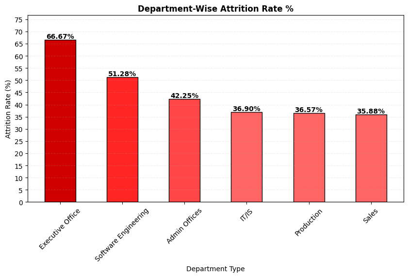

```python
import matplotlib.pyplot as plt

plt.figure(figsize=(10, 5))
colors = departmentWiseAttritionRate['attrition_rate'].apply(
    lambda i: '#D00000' if i > 60 else '#FF2525' if i > 50 else '#FF4747' if i > 40 else '#FF6565'
)
bars = plt.bar(departmentWiseAttritionRate['department_type'],
               departmentWiseAttritionRate['attrition_rate'],
               color=colors, width=0.5, edgecolor="black")

max_attrition = departmentWiseAttritionRate['attrition_rate'].max()


plt.ylim(0, max_attrition + 10)
plt.yticks(range(0, int(max_attrition) + 10, 5))

for bar in bars:
    plt.text(bar.get_x() + bar.get_width()/2,
             bar.get_height(),
             f'{bar.get_height():.2f}%',
             ha='center', va='bottom', fontsize=10, color='black', fontdict={'fontweight': 'semibold'})

plt.xlabel('Department Type')
plt.ylabel('Attrition Rate (%)')
plt.title('Department-Wise Attrition Rate %', fontdict={'fontsize': 12, 'fontweight': 'semibold'})
plt.xticks(rotation=45)
plt.grid(axis='y', linestyle='--', alpha=0.2)

plt.show()
```

##### Employee Classification Type Wise Attrition Rate (%)

```python
classification_type_wise_attrition_rate = '''
WITH exits AS (
    SELECT
        TRIM(employee_classification_type) AS classification_type,
        COUNT(*) AS exits
    FROM cleaned_hr_data
    WHERE exit_date BETWEEN '2023-01-01' AND '2023-08-31'
    GROUP BY classification_type
),

headcount_start AS (
    SELECT
        TRIM(employee_classification_type) AS classification_type,
        COUNT(*) AS headcount_start
    FROM cleaned_hr_data
    WHERE start_date <= '2023-01-01'
          AND (exit_date IS NULL OR exit_date >= '2023-01-01')
    GROUP BY classification_type
),

headcount_end AS (
    SELECT
        TRIM(employee_classification_type) AS classification_type,
        COUNT(*) AS headcount_end
    FROM cleaned_hr_data
    WHERE start_date <= '2023-08-31'
          AND (exit_date IS NULL OR exit_date >= '2023-08-31')
    GROUP BY classification_type
)

SELECT
    h_start.classification_type,
    e.exits,
    h_start.headcount_start,
    h_end.headcount_end,
    ROUND((e.exits / NULLIF((h_start.headcount_start + h_end.headcount_end) / 2.0, 0)) * 100, 2) AS attrition_rate
FROM headcount_start h_start
JOIN headcount_end h_end ON h_start.classification_type = h_end.classification_type
LEFT JOIN exits e ON h_start.classification_type = e.classification_type
ORDER BY attrition_rate DESC;
'''

classificationTypeWiseAttritionRate = pd.read_sql_query(classification_type_wise_attrition_rate, engine)

classificationTypeWiseAttritionRate
```

|  | classification_type | exits | headcount_start | headcount_end | attrition_rate |
| --- | --- | --- | --- | --- | --- |
| 0 | Temporary | 227 | 609 | 504 | 40.79 |
| 1 | Full-Time | 217 | 636 | 537 | 37.00 |
| 2 | Part-Time | 183 | 575 | 503 | 33.95 |

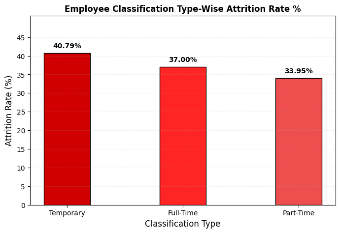

```python
import matplotlib.pyplot as plt

plt.figure(figsize=(8, 5))
colors = classificationTypeWiseAttritionRate['attrition_rate'].apply(
    lambda i: '#D00000' if i > 40 else '#FF2525' if i > 35 else '#EE4E4E'
)
bars = plt.bar(classificationTypeWiseAttritionRate['classification_type'],
               classificationTypeWiseAttritionRate['attrition_rate'],
               color=colors, width=0.4, edgecolor="black")

max_attrition = classificationTypeWiseAttritionRate['attrition_rate'].max()


plt.ylim(0, max_attrition + 10)
plt.yticks(range(0, int(max_attrition) + 10, 5))

for bar in bars:
    plt.text(bar.get_x() + bar.get_width() / 2,
             bar.get_height() + 1,
             f'{bar.get_height():.2f}%',
             ha='center', va='bottom', fontsize=10, color='black', fontweight='semibold')

plt.xlabel('Classification Type', fontsize=12)
plt.ylabel('Attrition Rate (%)', fontsize=12)
plt.title('Employee Classification Type-Wise Attrition Rate %', fontsize=12, fontweight='semibold')

plt.xticks(rotation=0)
plt.grid(axis='y', linestyle='--', alpha=0.2)

plt.show()
```

##### Monthly Attrition Rate (%)

```python
monthly_attrition_rate = """
WITH monthly_exits AS (
    SELECT
        DATE_FORMAT(exit_date, '%%Y-%%m') AS month_year,
        COUNT(*) AS exits
    FROM hr_analytics.cleaned_hr_data
    WHERE exit_date BETWEEN '2023-01-01' AND '2023-08-31'
    GROUP BY month_year
),
headcount_start AS (
    SELECT
        DATE_FORMAT(start_date, '%%Y-%%m') AS month_year,
        COUNT(*) AS start_count
    FROM hr_analytics.cleaned_hr_data
    WHERE start_date <= '2023-08-31'
    GROUP BY month_year
),
headcount_end AS (
    SELECT
        DATE_FORMAT(start_date, '%%Y-%%m') AS month_year,
        COUNT(*) AS end_count
    FROM hr_analytics.cleaned_hr_data
    WHERE start_date <= '2023-08-31'
    AND (exit_date IS NULL OR exit_date > LAST_DAY(start_date))
    GROUP BY month_year
)
SELECT
    months.month_year,
    COALESCE(me.exits, 0) AS exits,
    COALESCE(hs.start_count, 0) AS headcount_start,
    COALESCE(he.end_count, 0) AS headcount_end,
    ROUND(((COALESCE(hs.start_count, 0) + COALESCE(he.end_count, 0)) / 2), 2) AS avg_headcount,
    ROUND((COALESCE(me.exits, 0) / NULLIF(((COALESCE(hs.start_count, 0) + COALESCE(he.end_count, 0)) / 2), 0)) * 100, 2) AS attrition_rate
FROM (
    SELECT month_year FROM headcount_start WHERE month_year BETWEEN '2023-01' AND '2023-08'
    UNION
    SELECT month_year FROM headcount_end WHERE month_year BETWEEN '2023-01' AND '2023-08'
    UNION
    SELECT month_year FROM monthly_exits WHERE month_year BETWEEN '2023-01' AND '2023-08'
) AS months
LEFT JOIN headcount_start hs ON months.month_year = hs.month_year
LEFT JOIN headcount_end he ON months.month_year = he.month_year
LEFT JOIN monthly_exits me ON months.month_year = me.month_year
ORDER BY months.month_year;
"""

monthlyAttritionRate = pd.read_sql_query(monthly_attrition_rate, engine)
monthlyAttritionRate
```

|  | month_year | exits | headcount_start | headcount_end | avg_headcount | attrition_rate |
| --- | --- | --- | --- | --- | --- | --- |
| 0 | 2023-01 | 65 | 53 | 52 | 52.5 | 123.81 |
| 1 | 2023-02 | 65 | 39 | 38 | 38.5 | 168.83 |
| 2 | 2023-03 | 71 | 51 | 43 | 47.0 | 151.06 |
| 3 | 2023-04 | 64 | 55 | 55 | 55.0 | 116.36 |
| 4 | 2023-05 | 105 | 45 | 40 | 42.5 | 247.06 |
| 5 | 2023-06 | 95 | 40 | 39 | 39.5 | 240.51 |
| 6 | 2023-07 | 134 | 57 | 36 | 46.5 | 288.17 |
| 7 | 2023-08 | 28 | 14 | 10 | 12.0 | 233.33 |

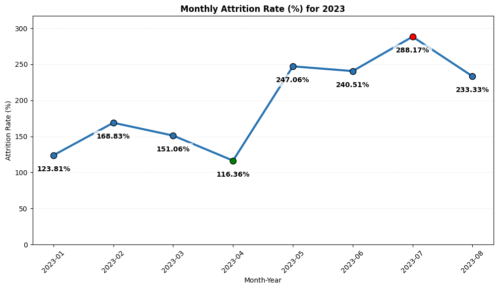

```python
import matplotlib.pyplot as plt

max_value = max(monthlyAttritionRate['attrition_rate'])
min_value = min(monthlyAttritionRate['attrition_rate'])

plt.figure(figsize=(12, 6))

plt.plot(monthlyAttritionRate['month_year'],
         monthlyAttritionRate['attrition_rate'],
         linestyle='-', color='#2973B2', linewidth=3)

for i, value in enumerate(monthlyAttritionRate['attrition_rate']):
    if value == max_value:
        color = 'red'
    elif value == min_value:
        color = 'green'
    else:
        color = '#2973B2'
    plt.scatter(monthlyAttritionRate['month_year'][i], value, color=color, s=80, edgecolors='black', zorder=3)

    plt.text(monthlyAttritionRate['month_year'][i],
             value - (max_value * 0.05),
             f'{value:.2f}%',
             ha='center', va='top', fontsize=10, color='black', fontdict={'fontweight': 'semibold'},
             bbox=dict(facecolor='white', edgecolor='none', alpha=0.7))

plt.xlabel('Month-Year')
plt.ylabel('Attrition Rate (%)')
plt.title('Monthly Attrition Rate (%) for 2023', fontdict={'fontsize': 12, 'fontweight': 'semibold'})

plt.xticks(rotation=45)

plt.ylim(0, max_value * 1.1)

plt.grid(axis='y', linestyle='--', alpha=0.2)

plt.show()
```

##### Question-2: Performance & Exit Insights "I suspect that employees with low satisfaction scores are more likely to leave. Can you analyze whether employees who have exited had lower satisfaction and engagement scores compared to those still active?"

```python
active_vs_exited_employees_performance = '''
with exited_engagement_score as (SELECT
    engagement_score as exited_engagement_score, COUNT(*) AS total_employees
FROM
    cleaned_hr_data
WHERE exit_date IS NOT NULL AND engagement_score < 3
GROUP BY engagement_score
ORDER BY engagement_score),
exited_satisfaction_score as (
SELECT
    satisfaction_score as exited_satisfaction_score, COUNT(*) AS total_employees
FROM
    cleaned_hr_data
WHERE exit_date IS NOT NULL AND satisfaction_score < 3
GROUP BY satisfaction_score
ORDER BY satisfaction_score),
active_engagement_score as (SELECT
    engagement_score as active_engagement_score, COUNT(*) AS total_employees
FROM
    cleaned_hr_data
WHERE exit_date IS NULL AND engagement_score < 3
GROUP BY engagement_score
ORDER BY engagement_score),
active_satisfaction_score as (
SELECT
    satisfaction_score as active_satisfaction_score, COUNT(*) AS total_employees
FROM
    cleaned_hr_data
WHERE exit_date IS NULL AND satisfaction_score < 3
GROUP BY satisfaction_score
ORDER BY satisfaction_score)

SELECT
    ROUND(AVG(s.total_employees), 2) AS avg_exited_employees_with_below_3_satisfaction_score,
    ROUND(AVG(e.total_employees), 2) AS avg_exited_employees_with_below_3_engagement_score,
    ROUND(AVG(active_s.total_employees), 2) AS avg_active_employees_with_below_3_satisfaction_score,
    ROUND(AVG(active_e.total_employees), 2) AS avg_active_employees_with_below_3_engagement_score
FROM
    active_satisfaction_score active_s,
    active_engagement_score active_e,
    exited_satisfaction_score s,
    exited_engagement_score e;
'''

activeVsExitedEmployeesPerformance = pd.read_sql_query(active_vs_exited_employees_performance, engine)

activeVsExitedEmployeesPerformance
```

|  | avg_exited_employees_with_below_3_satisfaction_score | avg_exited_employees_with_below_3_engagement_score | avg_active_employees_with_below_3_satisfaction_score | avg_active_employees_with_below_3_engagement_score |
| --- | --- | --- | --- | --- |
| 0 | 315.5 | 345.5 | 295.0 | 320.0 |

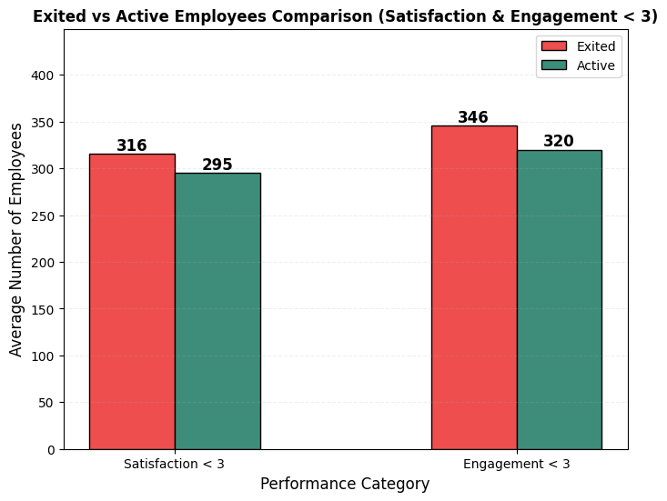

```python
import pandas as pd
import matplotlib.pyplot as plt
import numpy as np

df = activeVsExitedEmployeesPerformance

df.columns = [
    "Exited (Satisfaction < 3)",
    "Exited (Engagement < 3)",
    "Active (Satisfaction < 3)",
    "Active (Engagement < 3)"
]

categories = ["Satisfaction < 3", "Engagement < 3"]
exited_values = [df.iloc[0]["Exited (Satisfaction < 3)"], df.iloc[0]["Exited (Engagement < 3)"]]
active_values = [df.iloc[0]["Active (Satisfaction < 3)"], df.iloc[0]["Active (Engagement < 3)"]]

x = np.arange(len(categories))
width = 0.25

fig, ax = plt.subplots(figsize=(8, 6))

bars1 = ax.bar(x - width/2, exited_values, width, color="#EE4E4E", label="Exited", edgecolor="black")
bars2 = ax.bar(x + width/2, active_values, width, color="#3D8D7A", label="Active", edgecolor="black")

for bar in bars1 + bars2:
    height = bar.get_height()
    ax.text(bar.get_x() + bar.get_width()/2, height, f'{height:.0f}',
            ha='center', va='bottom', fontsize=12, fontweight='bold')

ax.set_xlabel("Performance Category", fontsize=12)
ax.set_ylabel("Average Number of Employees", fontsize=12)
ax.set_title("Exited vs Active Employees Comparison (Satisfaction & Engagement < 3)", fontsize=12, fontweight='semibold')

ax.set_ylim(0, max(max(exited_values), max(active_values)) * 1.3)
ax.yaxis.set_major_locator(plt.MaxNLocator(integer=True))

ax.yaxis.grid(True, linestyle="--", alpha=0.2)

ax.set_xticks(x)
ax.set_xticklabels(categories)
ax.legend()

plt.show()
```

##### Question-3: Training Effectiveness on Performance "We’ve been investing heavily in training programs. Can you analyze whether employees who completed training in the past year have a lower attrition rate compared to those who didn’t?"

```python
attrition_rate_between_trained_and_untrained_employees = '''
WITH trained_employees AS (
    SELECT employee_id
    FROM hr_analytics.cleaned_hr_data
    WHERE training_date BETWEEN '2023-08-01' - INTERVAL 11 MONTH AND '2023-08-31' AND training_outcome IN ('Completed', 'Passed')
),
attrition_data AS (
    SELECT
        CASE
            WHEN e.employee_id IN (SELECT employee_id FROM trained_employees) THEN 'Trained'
            ELSE 'Not Trained'
        END AS training_status,
        COUNT(*) AS total_employees,
        SUM(CASE WHEN e.exit_date IS NOT NULL THEN 1 ELSE 0 END) AS exited_employees
    FROM hr_analytics.cleaned_hr_data e
    GROUP BY training_status
)
SELECT
    training_status,
    total_employees,
    exited_employees,
    ROUND((exited_employees / NULLIF(total_employees, 0)) * 100, 2) AS attrition_rate
FROM attrition_data;
'''

attritionRateBetweenTrainedAndUntrainedEmployees = pd.read_sql_query(attrition_rate_between_trained_and_untrained_employees, engine)

attritionRateBetweenTrainedAndUntrainedEmployees
```

|  | training_status | total_employees | exited_employees | attrition_rate |
| --- | --- | --- | --- | --- |
| 0 | Not Trained | 1663 | 895.0 | 53.82 |
| 1 | Trained | 1487 | 711.0 | 47.81 |

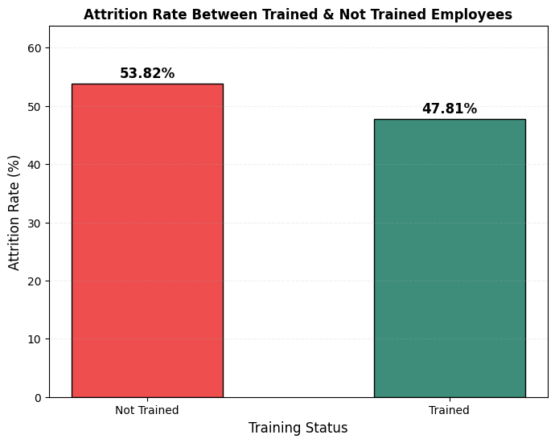

```python
import matplotlib.pyplot as plt

fig, ax = plt.subplots(figsize=(8, 6))
ax.bar(
    attritionRateBetweenTrainedAndUntrainedEmployees["training_status"],
    attritionRateBetweenTrainedAndUntrainedEmployees["attrition_rate"],
    color=["#EE4E4E", "#3D8D7A"], width=0.5, edgecolor="black"
)

ax.set_xlabel("Training Status", fontsize=12)
ax.set_ylabel("Attrition Rate (%)", fontsize=12)
ax.set_title("Attrition Rate Between Trained & Not Trained Employees", fontsize=12, fontweight='semibold')

max_attrition = attritionRateBetweenTrainedAndUntrainedEmployees["attrition_rate"].max()
ax.set_ylim(0, max_attrition + 10)
ax.set_yticks(range(0, int(max_attrition) + 10, 10))

ax.set_xticks(range(len(attritionRateBetweenTrainedAndUntrainedEmployees["training_status"])))
ax.set_xticklabels(attritionRateBetweenTrainedAndUntrainedEmployees["training_status"], rotation=0)

for i, v in enumerate(attritionRateBetweenTrainedAndUntrainedEmployees["attrition_rate"]):
    ax.text(i, v + 1, f"{v:.2f}%", ha='center', fontsize=12, fontweight='semibold')

ax.yaxis.grid(True, linestyle="--", alpha=0.2)

plt.show()
```

##### Question-4: Diversity & Inclusion Hiring Metrics "I need to prepare a report for leadership on our diversity hiring efforts. Can you provide a breakdown of new hires in the past two years by gender and job function?"

```python
diversity_metrices = '''
SELECT
    job_function_description,
    gender_code,
    COUNT(*) AS new_hires
FROM
    cleaned_hr_data
WHERE
    start_date >= DATE_SUB('2023-08-31', INTERVAL 2 YEAR)
        AND start_date <= '2023-08-31'
GROUP BY job_function_description , gender_code
ORDER BY job_function_description , gender_code;
'''
diversityMetrices = pd.read_sql_query(diversity_metrices, engine)

diversityMetrices
```

|  | job_function_description | gender_code | new_hires |
| --- | --- | --- | --- |
| 0 | Accountant | Female | 1 |
| 1 | Accounting | Female | 1 |
| 2 | Accounting | Male | 3 |
| 3 | Administration | Female | 2 |
| 4 | Administration | Male | 4 |
| ... | ... | ... | ... |
| 100 | Traffic | Female | 1 |
| 101 | Vp | Female | 3 |
| 102 | Vp | Male | 8 |
| 103 | Warehouse | Male | 2 |
| 104 | Warehouse Technician | Female | 2 |

105 rows × 3 columns

```python
#%pip install mplcursors
# %pip install seaborn
```

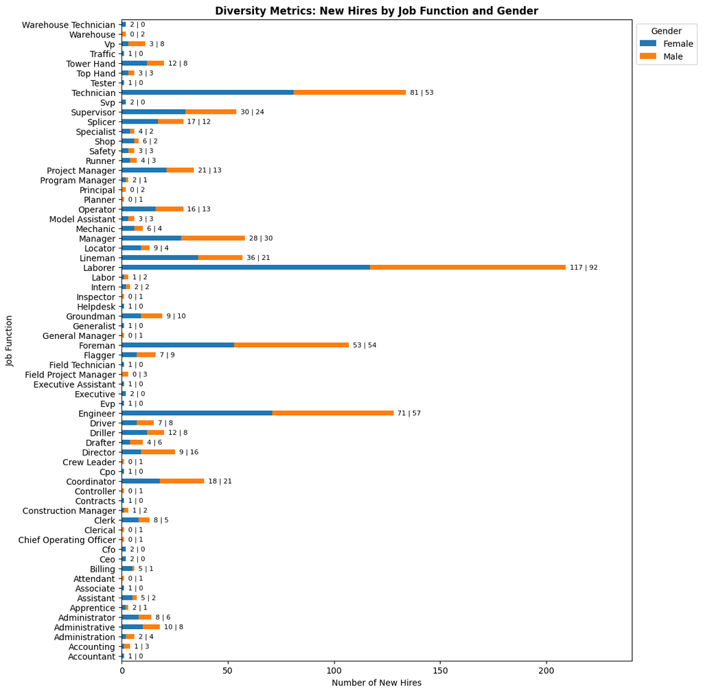

```python
import matplotlib.pyplot as plt

pivot_df = diversityMetrices.pivot(index="job_function_description", columns="gender_code", values="new_hires").fillna(0)

fig, ax = plt.subplots(figsize=(14, len(pivot_df) * 0.2))

colors = ["#1f77b4", "#ff7f0e"]

pivot_df.plot(kind="barh", stacked=True, color=colors[:len(pivot_df.columns)], ax=ax)

for index, (job_function, row) in enumerate(pivot_df.iterrows()):
    gender_counts = [int(row.get(gender, 0)) for gender in pivot_df.columns]
    total = sum(gender_counts)

    if total > 0:
        label_text = " | ".join(str(count) for count in gender_counts)
        ax.text(total + 2, index, label_text, va='center', fontsize=8, fontweight='normal')


ax.set_xlabel("Number of New Hires")
ax.set_ylabel("Job Function")
ax.set_title("Diversity Metrics: New Hires by Job Function and Gender", fontdict={'fontsize': 12, 'fontweight': 'semibold'})
ax.legend(title="Gender", bbox_to_anchor=(1, 1), loc='upper left')


plt.subplots_adjust(left=0.2, right=0.8, top=0.9, bottom=0.1)
plt.gca().margins(x=0.15, y=0.01)

plt.show()
```

##### Question-5: Work-Life Balance & Retention "Some employees have raised concerns about work-life balance. Can you analyze whether employees with low work-life balance scores are more likely to leave or have lower performance ratings?"

```python
work_life_balance_vs_attrition_rate = '''
WITH exit_employees_ratings AS (SELECT
    performance_score,
    COUNT(*) AS total_employees,
    COUNT(exit_date) AS exits,
    ROUND(AVG(worklife_balance_score), 2) AS avg_work_life_balance_rating
FROM
    cleaned_hr_data
GROUP BY performance_score
)

SELECT
    performance_score,
    total_employees,
    exits,
    avg_work_life_balance_rating,
    ROUND((exits / total_employees) * 100, 2) AS attrition_rate
FROM
    exit_employees_ratings
ORDER BY attrition_rate DESC;
'''

workLifeBalanceVsAttritionRate = pd.read_sql_query(work_life_balance_vs_attrition_rate, engine)

workLifeBalanceVsAttritionRate
```

|  | performance_score | total_employees | exits | avg_work_life_balance_rating | attrition_rate |
| --- | --- | --- | --- | --- | --- |
| 0 | PIP | 97 | 51 | 2.99 | 52.58 |
| 1 | Needs Improvement | 184 | 94 | 2.91 | 51.09 |
| 2 | Fully Meets | 2486 | 1268 | 3.00 | 51.01 |
| 3 | Exceeds | 383 | 193 | 2.95 | 50.39 |

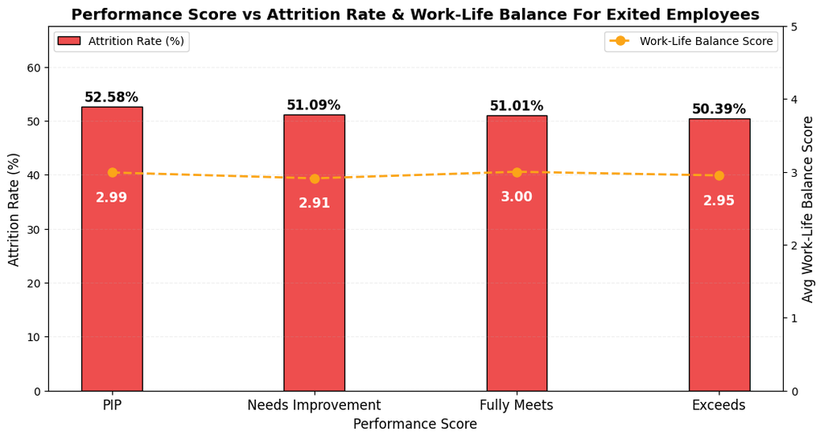

```python
import matplotlib.pyplot as plt
import numpy as np

x = workLifeBalanceVsAttritionRate["performance_score"]
y1 = workLifeBalanceVsAttritionRate["attrition_rate"]
y2 = workLifeBalanceVsAttritionRate["avg_work_life_balance_rating"]

fig, ax1 = plt.subplots(figsize=(12, 6))

bars = ax1.bar(x, y1, color="#EE4E4E", width=0.3, edgecolor="black", label="Attrition Rate (%)")

ax2 = ax1.twinx()
ax2.plot(x, y2, color="#FBA518", marker="o", linestyle="--", linewidth=2, markersize=8, label="Work-Life Balance Score")

ax1.set_xlabel("Performance Score", fontsize=12)
ax1.set_ylabel("Attrition Rate (%)", fontsize=12)
ax2.set_ylabel("Avg Work-Life Balance Score", fontsize=12)
plt.title("Performance Score vs Attrition Rate & Work-Life Balance For Exited Employees", fontsize=14, fontweight="bold")

ax1.set_xticks(range(len(x)))
ax1.set_xticklabels(x, rotation=0, ha='center', fontsize=12)

ax1.set_ylim(0, max(y1) + 15)
ax2.set_ylim(0, max(y2) + 2)

for bar in bars:
    height = bar.get_height()
    ax1.text(bar.get_x() + bar.get_width()/2, height + 1, f"{height:.2f}%", ha="center", fontsize=12, fontweight="bold")

for i, txt in enumerate(y2):
    ax2.text(i, y2[i] - 0.4, f"{txt:.2f}", ha="center", fontsize=12, fontweight="bold", color="white")

ax1.grid(axis="y", linestyle="--", alpha=0.2)
ax1.legend(loc="upper left")
ax2.legend(loc="upper right")

plt.show()
```